# Science User Case - Inspecting a Candidate List

Ogle et al. (2016) mined the NASA/IPAC Extragalactic Database (NED) to identify a new type of galaxy: Superluminous Spiral Galaxies.

Here's the paper: https://ui.adsabs.harvard.edu//#abs/2016ApJ...817..109O/abstract

Table 1 lists the positions of these Super Spirals. Based on those positions, let's create multiwavelength cutouts for each super spiral to see what is unique about this new class of objects.

## 1. Import the Python modules we'll be using.

```python
# Suppress unimportant warnings.
import warnings
warnings.filterwarnings("ignore", module="astropy.io.votable.*")
warnings.filterwarnings("ignore", module="pyvo.utils.xml.*")
warnings.filterwarnings('ignore', '.*RADECSYS=*', append=True)

import matplotlib.pyplot as plt
import numpy as np

# For downloading files
from astropy.utils.data import download_file

from astropy.coordinates import SkyCoord
from astropy.io import fits
from astropy.nddata import Cutout2D
import astropy.visualization as vis
from astropy.wcs import WCS
from astroquery.ned import Ned

import pyvo as vo
```

The next cell prepares the notebook to display our visualizations.

```python
%matplotlib inline
```

## 2. Search NED for objects in this paper.

Insert a Code Cell below by clicking on the "Insert" Menu and choosing "Insert Cell Below". Then consult QuickReference.md to figure out how to use astroquery to search NED for all objects in a paper, based on the refcode of the paper. Inspect the resulting astropy table.

```python
objects_in_paper = Ned.query_refcode('2016ApJ...817..109O')
objects_in_paper.show_in_notebook()
```

*Table length=62*

| idx | No. | Object Name | RA degrees | DEC degrees | Type | Velocity km / s | Redshift | Redshift Flag | Magnitude and Filter | Separation arcmin | References | Notes | Photometry Points | Positions | Redshift Points | Diameter Points | Associations |
| --- | --- | --- | --- | --- | --- | --- | --- | --- | --- | --- | --- | --- | --- | --- | --- | --- | --- |
| 0 | 1 | WISEA J001550.14-100242.3 | 3.95892 | -10.04511 | G | 52788.0 | 0.176083 |  | 17.5g | -- | 13 | 0 | 63 | 8 | 7 | 10 | 0 |
| 1 | 2 | WISEA J003807.80-010936.7 | 9.53252 | -1.16024 | G | 62565.0 | 0.208695 |  | 18.0g | -- | 14 | 0 | 71 | 12 | 9 | 10 | 0 |
| 2 | 3 | WISEA J040422.92-054134.8 | 61.09548 | -5.69303 | G | 75138.0 | 0.250635 |  | 18.6g | -- | 6 | 0 | 61 | 10 | 7 | 8 | 0 |
| 3 | 4 | WISEA J073806.16+282359.6 | 114.52568 | 28.39995 | G | 69255.0 | 0.23101 |  | 18.0g | -- | 9 | 0 | 66 | 7 | 4 | 10 | 0 |
| 4 | 5 | 2MASX J07550424+1353261 | 118.76776 | 13.89065 | G | 66754.0 | 0.222669 |  | 18.5g | -- | 8 | 0 | 38 | 7 | 6 | 6 | 0 |
| 5 | 6 | WISEA J082655.11+181147.7 | 126.72969 | 18.19665 | G | 79608.0 | 0.265543 |  | 18.4g | -- | 6 | 0 | 46 | 7 | 6 | 6 | 0 |
| 6 | 7 | 2MASX J08542169+0449308 | 133.59033 | 4.82511 | G | 47018.0 | 0.156835 |  | 16.7g | -- | 16 | 0 | 58 | 8 | 6 | 10 | 0 |
| 7 | 8 | WHL J090944.8+222607 | 137.4367 | 22.43539 | GClstr | 90837.0 | 0.303 | PHOT |  | -- | 7 | 0 | 0 | 4 | 5 | 0 | 0 |
| 8 | 9 | 2MASX J09094480+2226078 | 137.4367 | 22.43538 | G | 85557.0 | 0.285386 |  | 19.0g | -- | 8 | 0 | 30 | 5 | 6 | 6 | 0 |
| 9 | 10 | 2MASX J09260805+2405242 | 141.53357 | 24.09004 | G | 66689.0 | 0.222451 |  | 17.8g | -- | 14 | 0 | 32 | 7 | 9 | 6 | 0 |
| 10 | 11 | WHL J092608.1+240524 | 141.53357 | 24.09004 | GClstr | 53363.0 | 0.178 | PHOT |  | -- | 6 | 0 | 0 | 4 | 5 | 0 | 0 |
| 11 | 12 | WISEA J093347.77+211436.7 | 143.44901 | 21.24346 | G | 51626.0 | 0.172206 |  | 16.9g | -- | 42 | 0 | 51 | 17 | 13 | 6 | 1 |
| 12 | 13 | WISEA J093622.14+390628.9 | 144.09222 | 39.10801 | G | 84847.0 | 0.283019 |  | 18.5g | -- | 5 | 0 | 66 | 7 | 3 | 10 | 0 |
| 13 | 14 | MSPM 05544 | 146.2235 | 22.8851 | GClstr | 26738.0 | 0.08919 |  |  | -- | 3 | 0 | 0 | 1 | 1 | 0 | 0 |
| 14 | 15 | CGCG 122-067 | 146.22351 | 22.88512 | G | 26684.0 | 0.089008 |  | 15.3g | -- | 27 | 0 | 48 | 9 | 9 | 8 | 0 |
| 15 | 16 | WISEA J094700.08+254045.8 | 146.75035 | 25.67938 | G | 32710.0 | 0.10911 |  | 15.8g | -- | 19 | 0 | 46 | 7 | 7 | 6 | 0 |
| 16 | 17 | SDSS J095727.02+083501.7 | 149.36259 | 8.58383 | G | 76917.0 | 0.256568 |  | 18.3g | -- | 7 | 0 | 39 | 5 | 3 | 8 | 0 |
| 17 | 18 | WISEA J100356.88+382902.1 | 150.98703 | 38.48391 | G | 77544.0 | 0.258658 |  | 17.8g | -- | 7 | 0 | 57 | 7 | 4 | 8 | 0 |
| 18 | 19 | WISEA J100416.04+295844.1 | 151.06683 | 29.97899 | G | 89469.0 | 0.298435 |  | 18.7g | -- | 6 | 0 | 66 | 7 | 4 | 10 | 0 |
| 19 | 20 | WISEA J100956.35+261132.0 | 152.48475 | 26.19223 | G | 72232.0 | 0.240939 |  | 18.1g | -- | 11 | 0 | 46 | 7 | 4 | 6 | 0 |
| 20 | 21 | GMBCG J152.52936+32.89139 | 152.52936 | 32.89139 | GClstr | 95634.0 | 0.319 | PHOT |  | -- | 3 | 0 | 0 | 1 | 1 | 0 | 0 |
| 21 | 22 | WISEA J101007.05+325329.0 | 152.52936 | 32.89141 | G | 86914.0 | 0.289913 |  | 18.7g | -- | 9 | 0 | 66 | 7 | 4 | 10 | 0 |
| 22 | 23 | 2MASS J10160396+3037481 | 154.01655 | 30.62998 | G | 75553.0 | 0.252016 |  | 18.7g | -- | 6 | 0 | 49 | 7 | 4 | 8 | 0 |
| 23 | 24 | WISEA J102154.85+072415.5 | 155.47856 | 7.40432 | G | 87111.0 | 0.29057 |  | 18.4g | -- | 5 | 0 | 55 | 7 | 3 | 8 | 0 |
| 24 | 25 | WISEA J103015.74-010607.0 | 157.56561 | -1.10198 | G | 84617.0 | 0.282251 |  | 18.3g | -- | 10 | 0 | 62 | 9 | 6 | 10 | 0 |
| 25 | 26 | 2MASX J10304263+0418219 | 157.67753 | 4.30602 | G | 48300.0 | 0.16111 |  | 16.8g | -- | 21 | 0 | 59 | 8 | 6 | 10 | 0 |
| 26 | 27 | SDSS CE J160.241898-01.069106 | 160.235 | -1.06611 | GClstr | 76153.0 | 0.254019 | EST |  | -- | 6 | 0 | 0 | 3 | 5 | 0 | 0 |
| 27 | 28 | 2MASX J10405643-0103584 | 160.23509 | -1.06632 | G | 75039.0 | 0.250303 |  | 18.2g | -- | 15 | 0 | 51 | 9 | 9 | 10 | 0 |
| 28 | 29 | WISEA J104724.97+230917.4 | 161.85435 | 23.15474 | G | 54754.0 | 0.182639 |  | 18.46 | -- | 17 | 0 | 46 | 8 | 6 | 6 | 0 |
| 29 | 30 | WISEA J111917.41+141946.5 | 169.8226 | 14.3296 | G | 43104.0 | 0.143781 |  | 16.6g | -- | 18 | 0 | 66 | 8 | 6 | 10 | 0 |
| 30 | 31 | 2MASS J11292875+0255498 | 172.36978 | 2.93055 | G | 71860.0 | 0.239698 |  | 17.5g | -- | 8 | 0 | 49 | 7 | 5 | 8 | 0 |
| 31 | 32 | WISEA J113800.86+521303.8 | 174.50367 | 52.21775 | G | 88744.0 | 0.296018 |  | 19.0g | -- | 8 | 0 | 57 | 7 | 3 | 8 | 0 |
| 32 | 33 | WISEA J114100.04+384807.4 | 175.25022 | 38.80207 | G | 80215.0 | 0.267567 |  | 18.5g | -- | 6 | 0 | 66 | 8 | 6 | 10 | 0 |
| 33 | 34 | WISEA J115052.96+460448.1 | 177.72076 | 46.08006 | G | 86801.0 | 0.289538 |  | 18.5g | -- | 10 | 0 | 53 | 9 | 7 | 8 | 0 |
| 34 | 35 | WISEA J115356.21+492355.4 | 178.48416 | 49.39881 | G | 50033.0 | 0.166892 |  | 17.1g | -- | 16 | 0 | 66 | 9 | 6 | 10 | 0 |
| 35 | 36 | 2MASX J11593546+1257080 | 179.89761 | 12.95205 | G | 79017.0 | 0.263572 |  | 18.3g | -- | 6 | 0 | 54 | 6 | 4 | 10 | 0 |
| 36 | 37 | WISEA J120053.92+480007.8 | 180.22477 | 48.00213 | G | 83527.0 | 0.278617 |  | 18.4g | -- | 7 | 0 | 66 | 7 | 5 | 10 | 0 |
| 37 | 38 | GMBCG J180.22479+48.00211 | 180.22479 | 48.00211 | GClstr | 75548.0 | 0.252 | PHOT |  | -- | 5 | 0 | 0 | 2 | 3 | 0 | 0 |
| 38 | 39 | WISEA J121644.33+122450.5 | 184.18477 | 12.41404 | G | 77090.0 | 0.257144 |  | 18.3g | -- | 5 | 0 | 55 | 7 | 3 | 8 | 0 |
| 39 | 40 | WISEA J122100.50+482729.1 | 185.25209 | 48.45807 | G | 89874.0 | 0.299787 |  | 18.7g | -- | 8 | 0 | 61 | 8 | 3 | 8 | 0 |
| 40 | 41 | WISEA J123215.19+102119.1 | 188.06311 | 10.35535 | G | 49742.0 | 0.16592 |  | 17.2g | -- | 17 | 0 | 66 | 9 | 6 | 10 | 0 |
| 41 | 42 | WISEA J123431.08+515629.7 | 188.62952 | 51.94146 | G | 88733.0 | 0.295982 |  | 18.1g | -- | 28 | 0 | 63 | 10 | 11 | 10 | 0 |
| 42 | 43 | WISEA J123746.63+481227.5 | 189.44448 | 48.20767 | G | 81721.0 | 0.272592 |  | 18.2g | -- | 7 | 0 | 64 | 8 | 4 | 10 | 0 |
| 43 | 44 | WISEA J131039.32+223502.8 | 197.66385 | 22.58407 | G | 69341.0 | 0.231295 |  | 18.1g | -- | 10 | 0 | 48 | 8 | 5 | 6 | 1 |
| 44 | 45 | WISEA J132757.52+334529.3 | 201.98969 | 33.75806 | G | 74633.0 | 0.248949 |  | 17.7g | -- | 14 | 0 | 88 | 12 | 4 | 10 | 0 |
| 45 | 46 | WISEA J134228.33+115734.5 | 205.61806 | 11.95954 | G | 83682.0 | 0.279133 |  | 19.0g | -- | 7 | 0 | 66 | 7 | 4 | 10 | 0 |
| 46 | 47 | WISEA J134355.49+244048.1 | 205.98124 | 24.68001 | G | 41149.0 | 0.137258 |  | 17.81 | -- | 17 | 0 | 46 | 8 | 6 | 6 | 0 |
| 47 | 48 | SDSSCGB 16827 | 206.99833 | 32.44039 | GGroup | -- | -- |  | 18.44 | -- | 3 | 0 | 0 | 1 | 0 | 0 | 0 |
| 48 | 49 | 2MASX J13475962+3227100 | 206.99841 | 32.45286 | G | 66888.0 | 0.223113 |  | 18.1g | -- | 10 | 0 | 54 | 6 | 4 | 10 | 0 |
| 49 | 50 | WISEA J135546.08+025456.0 | 208.942 | 2.91553 | G | 71617.0 | 0.23889 |  | 18.7g | -- | 10 | 0 | 51 | 7 | 5 | 8 | 0 |
| 50 | 51 | WISEA J140138.37+263527.6 | 210.40991 | 26.591 | G | 85152.0 | 0.284036 |  | 18.7g | -- | 7 | 0 | 30 | 5 | 4 | 4 | 0 |
| 51 | 52 | 2MASS J14175497+2704341 | 214.47905 | 27.07624 | G | 47238.0 | 0.157569 |  | 16.9g | -- | 16 | 0 | 25 | 6 | 6 | 4 | 0 |
| 52 | 53 | WISEA J143447.88+020228.8 | 218.69942 | 2.04129 | G | 83976.0 | 0.280115 |  | 18.6g | -- | 8 | 0 | 62 | 9 | 5 | 8 | 0 |
| 53 | 54 | WISEA J144728.35+590831.9 | 221.86807 | 59.14209 | G | 73609.0 | 0.245534 |  | 18.3g | -- | 14 | 0 | 69 | 11 | 8 | 10 | 0 |
| 54 | 55 | WISEA J153619.01+452247.7 | 234.07909 | 45.37968 | G | 70813.0 | 0.236206 |  | 18.1g | -- | 8 | 0 | 57 | 7 | 3 | 8 | 0 |
| 55 | 56 | WISEA J154307.78+193751.7 | 235.78241 | 19.63104 | G | 68625.0 | 0.228909 |  | 17.0g | -- | 34 | 1 | 50 | 16 | 14 | 6 | 0 |
| 56 | 57 | WISEA J154950.90+234444.0 | 237.46216 | 23.7456 | G | 78611.0 | 0.262217 |  | 18.5g | -- | 6 | 0 | 31 | 5 | 4 | 4 | 0 |
| 57 | 58 | GMBCG J240.41924+27.30444 | 240.41924 | 27.30444 | GClstr | 57860.0 | 0.193 | PHOT |  | -- | 3 | 0 | 0 | 1 | 1 | 0 | 0 |
| 58 | 59 | 2MASX J16014061+2718161 | 240.41924 | 27.30443 | G | 49332.0 | 0.164554 |  | 16.7g | -- | 19 | 0 | 54 | 7 | 7 | 10 | 1 |
| 59 | 60 | WISEA J163945.96+460905.8 | 249.94148 | 46.1517 | G | 74151.0 | 0.247342 |  | 18.3g | -- | 10 | 0 | 70 | 8 | 4 | 10 | 0 |
| 60 | 61 | WISEA J173406.17+602919.1 | 263.52577 | 60.48859 | G | 82685.0 | 0.275807 |  | 18.5g | -- | 8 | 0 | 66 | 7 | 4 | 10 | 0 |
| 61 | 62 | SDSSCGB 59704 | 263.53292 | 60.48197 | GGroup | 82743.0 | 0.276 |  | 17.20 | -- | 3 | 0 | 0 | 1 | 1 | 0 | 0 |

## 3. Filter the NED results.

The results from NED will include galaxies, but also other kinds of objects. Print the 'Type' column to see the full range of classifications. Next, print the 'Type' of just the first source in the table, in order to determine its data type (since Python 3 distinguishes between strings and byte strings). Finally, use the data type information to filter the results so that we only keep the galaxies in the list.

```python
objects_in_paper['Type']
```

<MaskedColumn name='Type' dtype='object' description="NED's Preferred Object Type: G,GPair,GTrpl,GGroup,GClstr,QSO,AbLS,RadioS,IrS,EmLS,UvES,XrayS,SN" length=62>

| G |
| --- |
| G |
| G |
| G |
| G |
| G |
| G |
| GClstr |
| G |
| G |
| GClstr |
| G |
| ... |
| G |
| G |
| G |
| G |
| G |
| G |
| G |
| GClstr |
| G |
| G |
| G |
| GGroup |

```python
# Let's see whether we are dealing with strings or byte strings
objects_in_paper[0]['Type']
```

```
'G'
```

```python
# Recast the Type column as strings, to avoid any issues with byte strings
galaxies = objects_in_paper[np.array(objects_in_paper['Type'], dtype='str') == 'G']

galaxies.show_in_notebook()
```

*Table length=53*

| idx | No. | Object Name | RA degrees | DEC degrees | Type | Velocity km / s | Redshift | Redshift Flag | Magnitude and Filter | Separation arcmin | References | Notes | Photometry Points | Positions | Redshift Points | Diameter Points | Associations |
| --- | --- | --- | --- | --- | --- | --- | --- | --- | --- | --- | --- | --- | --- | --- | --- | --- | --- |
| 0 | 1 | WISEA J001550.14-100242.3 | 3.95892 | -10.04511 | G | 52788.0 | 0.176083 |  | 17.5g | -- | 13 | 0 | 63 | 8 | 7 | 10 | 0 |
| 1 | 2 | WISEA J003807.80-010936.7 | 9.53252 | -1.16024 | G | 62565.0 | 0.208695 |  | 18.0g | -- | 14 | 0 | 71 | 12 | 9 | 10 | 0 |
| 2 | 3 | WISEA J040422.92-054134.8 | 61.09548 | -5.69303 | G | 75138.0 | 0.250635 |  | 18.6g | -- | 6 | 0 | 61 | 10 | 7 | 8 | 0 |
| 3 | 4 | WISEA J073806.16+282359.6 | 114.52568 | 28.39995 | G | 69255.0 | 0.23101 |  | 18.0g | -- | 9 | 0 | 66 | 7 | 4 | 10 | 0 |
| 4 | 5 | 2MASX J07550424+1353261 | 118.76776 | 13.89065 | G | 66754.0 | 0.222669 |  | 18.5g | -- | 8 | 0 | 38 | 7 | 6 | 6 | 0 |
| 5 | 6 | WISEA J082655.11+181147.7 | 126.72969 | 18.19665 | G | 79608.0 | 0.265543 |  | 18.4g | -- | 6 | 0 | 46 | 7 | 6 | 6 | 0 |
| 6 | 7 | 2MASX J08542169+0449308 | 133.59033 | 4.82511 | G | 47018.0 | 0.156835 |  | 16.7g | -- | 16 | 0 | 58 | 8 | 6 | 10 | 0 |
| 7 | 9 | 2MASX J09094480+2226078 | 137.4367 | 22.43538 | G | 85557.0 | 0.285386 |  | 19.0g | -- | 8 | 0 | 30 | 5 | 6 | 6 | 0 |
| 8 | 10 | 2MASX J09260805+2405242 | 141.53357 | 24.09004 | G | 66689.0 | 0.222451 |  | 17.8g | -- | 14 | 0 | 32 | 7 | 9 | 6 | 0 |
| 9 | 12 | WISEA J093347.77+211436.7 | 143.44901 | 21.24346 | G | 51626.0 | 0.172206 |  | 16.9g | -- | 42 | 0 | 51 | 17 | 13 | 6 | 1 |
| 10 | 13 | WISEA J093622.14+390628.9 | 144.09222 | 39.10801 | G | 84847.0 | 0.283019 |  | 18.5g | -- | 5 | 0 | 66 | 7 | 3 | 10 | 0 |
| 11 | 15 | CGCG 122-067 | 146.22351 | 22.88512 | G | 26684.0 | 0.089008 |  | 15.3g | -- | 27 | 0 | 48 | 9 | 9 | 8 | 0 |
| 12 | 16 | WISEA J094700.08+254045.8 | 146.75035 | 25.67938 | G | 32710.0 | 0.10911 |  | 15.8g | -- | 19 | 0 | 46 | 7 | 7 | 6 | 0 |
| 13 | 17 | SDSS J095727.02+083501.7 | 149.36259 | 8.58383 | G | 76917.0 | 0.256568 |  | 18.3g | -- | 7 | 0 | 39 | 5 | 3 | 8 | 0 |
| 14 | 18 | WISEA J100356.88+382902.1 | 150.98703 | 38.48391 | G | 77544.0 | 0.258658 |  | 17.8g | -- | 7 | 0 | 57 | 7 | 4 | 8 | 0 |
| 15 | 19 | WISEA J100416.04+295844.1 | 151.06683 | 29.97899 | G | 89469.0 | 0.298435 |  | 18.7g | -- | 6 | 0 | 66 | 7 | 4 | 10 | 0 |
| 16 | 20 | WISEA J100956.35+261132.0 | 152.48475 | 26.19223 | G | 72232.0 | 0.240939 |  | 18.1g | -- | 11 | 0 | 46 | 7 | 4 | 6 | 0 |
| 17 | 22 | WISEA J101007.05+325329.0 | 152.52936 | 32.89141 | G | 86914.0 | 0.289913 |  | 18.7g | -- | 9 | 0 | 66 | 7 | 4 | 10 | 0 |
| 18 | 23 | 2MASS J10160396+3037481 | 154.01655 | 30.62998 | G | 75553.0 | 0.252016 |  | 18.7g | -- | 6 | 0 | 49 | 7 | 4 | 8 | 0 |
| 19 | 24 | WISEA J102154.85+072415.5 | 155.47856 | 7.40432 | G | 87111.0 | 0.29057 |  | 18.4g | -- | 5 | 0 | 55 | 7 | 3 | 8 | 0 |
| 20 | 25 | WISEA J103015.74-010607.0 | 157.56561 | -1.10198 | G | 84617.0 | 0.282251 |  | 18.3g | -- | 10 | 0 | 62 | 9 | 6 | 10 | 0 |
| 21 | 26 | 2MASX J10304263+0418219 | 157.67753 | 4.30602 | G | 48300.0 | 0.16111 |  | 16.8g | -- | 21 | 0 | 59 | 8 | 6 | 10 | 0 |
| 22 | 28 | 2MASX J10405643-0103584 | 160.23509 | -1.06632 | G | 75039.0 | 0.250303 |  | 18.2g | -- | 15 | 0 | 51 | 9 | 9 | 10 | 0 |
| 23 | 29 | WISEA J104724.97+230917.4 | 161.85435 | 23.15474 | G | 54754.0 | 0.182639 |  | 18.46 | -- | 17 | 0 | 46 | 8 | 6 | 6 | 0 |
| 24 | 30 | WISEA J111917.41+141946.5 | 169.8226 | 14.3296 | G | 43104.0 | 0.143781 |  | 16.6g | -- | 18 | 0 | 66 | 8 | 6 | 10 | 0 |
| 25 | 31 | 2MASS J11292875+0255498 | 172.36978 | 2.93055 | G | 71860.0 | 0.239698 |  | 17.5g | -- | 8 | 0 | 49 | 7 | 5 | 8 | 0 |
| 26 | 32 | WISEA J113800.86+521303.8 | 174.50367 | 52.21775 | G | 88744.0 | 0.296018 |  | 19.0g | -- | 8 | 0 | 57 | 7 | 3 | 8 | 0 |
| 27 | 33 | WISEA J114100.04+384807.4 | 175.25022 | 38.80207 | G | 80215.0 | 0.267567 |  | 18.5g | -- | 6 | 0 | 66 | 8 | 6 | 10 | 0 |
| 28 | 34 | WISEA J115052.96+460448.1 | 177.72076 | 46.08006 | G | 86801.0 | 0.289538 |  | 18.5g | -- | 10 | 0 | 53 | 9 | 7 | 8 | 0 |
| 29 | 35 | WISEA J115356.21+492355.4 | 178.48416 | 49.39881 | G | 50033.0 | 0.166892 |  | 17.1g | -- | 16 | 0 | 66 | 9 | 6 | 10 | 0 |
| 30 | 36 | 2MASX J11593546+1257080 | 179.89761 | 12.95205 | G | 79017.0 | 0.263572 |  | 18.3g | -- | 6 | 0 | 54 | 6 | 4 | 10 | 0 |
| 31 | 37 | WISEA J120053.92+480007.8 | 180.22477 | 48.00213 | G | 83527.0 | 0.278617 |  | 18.4g | -- | 7 | 0 | 66 | 7 | 5 | 10 | 0 |
| 32 | 39 | WISEA J121644.33+122450.5 | 184.18477 | 12.41404 | G | 77090.0 | 0.257144 |  | 18.3g | -- | 5 | 0 | 55 | 7 | 3 | 8 | 0 |
| 33 | 40 | WISEA J122100.50+482729.1 | 185.25209 | 48.45807 | G | 89874.0 | 0.299787 |  | 18.7g | -- | 8 | 0 | 61 | 8 | 3 | 8 | 0 |
| 34 | 41 | WISEA J123215.19+102119.1 | 188.06311 | 10.35535 | G | 49742.0 | 0.16592 |  | 17.2g | -- | 17 | 0 | 66 | 9 | 6 | 10 | 0 |
| 35 | 42 | WISEA J123431.08+515629.7 | 188.62952 | 51.94146 | G | 88733.0 | 0.295982 |  | 18.1g | -- | 28 | 0 | 63 | 10 | 11 | 10 | 0 |
| 36 | 43 | WISEA J123746.63+481227.5 | 189.44448 | 48.20767 | G | 81721.0 | 0.272592 |  | 18.2g | -- | 7 | 0 | 64 | 8 | 4 | 10 | 0 |
| 37 | 44 | WISEA J131039.32+223502.8 | 197.66385 | 22.58407 | G | 69341.0 | 0.231295 |  | 18.1g | -- | 10 | 0 | 48 | 8 | 5 | 6 | 1 |
| 38 | 45 | WISEA J132757.52+334529.3 | 201.98969 | 33.75806 | G | 74633.0 | 0.248949 |  | 17.7g | -- | 14 | 0 | 88 | 12 | 4 | 10 | 0 |
| 39 | 46 | WISEA J134228.33+115734.5 | 205.61806 | 11.95954 | G | 83682.0 | 0.279133 |  | 19.0g | -- | 7 | 0 | 66 | 7 | 4 | 10 | 0 |
| 40 | 47 | WISEA J134355.49+244048.1 | 205.98124 | 24.68001 | G | 41149.0 | 0.137258 |  | 17.81 | -- | 17 | 0 | 46 | 8 | 6 | 6 | 0 |
| 41 | 49 | 2MASX J13475962+3227100 | 206.99841 | 32.45286 | G | 66888.0 | 0.223113 |  | 18.1g | -- | 10 | 0 | 54 | 6 | 4 | 10 | 0 |
| 42 | 50 | WISEA J135546.08+025456.0 | 208.942 | 2.91553 | G | 71617.0 | 0.23889 |  | 18.7g | -- | 10 | 0 | 51 | 7 | 5 | 8 | 0 |
| 43 | 51 | WISEA J140138.37+263527.6 | 210.40991 | 26.591 | G | 85152.0 | 0.284036 |  | 18.7g | -- | 7 | 0 | 30 | 5 | 4 | 4 | 0 |
| 44 | 52 | 2MASS J14175497+2704341 | 214.47905 | 27.07624 | G | 47238.0 | 0.157569 |  | 16.9g | -- | 16 | 0 | 25 | 6 | 6 | 4 | 0 |
| 45 | 53 | WISEA J143447.88+020228.8 | 218.69942 | 2.04129 | G | 83976.0 | 0.280115 |  | 18.6g | -- | 8 | 0 | 62 | 9 | 5 | 8 | 0 |
| 46 | 54 | WISEA J144728.35+590831.9 | 221.86807 | 59.14209 | G | 73609.0 | 0.245534 |  | 18.3g | -- | 14 | 0 | 69 | 11 | 8 | 10 | 0 |
| 47 | 55 | WISEA J153619.01+452247.7 | 234.07909 | 45.37968 | G | 70813.0 | 0.236206 |  | 18.1g | -- | 8 | 0 | 57 | 7 | 3 | 8 | 0 |
| 48 | 56 | WISEA J154307.78+193751.7 | 235.78241 | 19.63104 | G | 68625.0 | 0.228909 |  | 17.0g | -- | 34 | 1 | 50 | 16 | 14 | 6 | 0 |
| 49 | 57 | WISEA J154950.90+234444.0 | 237.46216 | 23.7456 | G | 78611.0 | 0.262217 |  | 18.5g | -- | 6 | 0 | 31 | 5 | 4 | 4 | 0 |
| 50 | 59 | 2MASX J16014061+2718161 | 240.41924 | 27.30443 | G | 49332.0 | 0.164554 |  | 16.7g | -- | 19 | 0 | 54 | 7 | 7 | 10 | 1 |
| 51 | 60 | WISEA J163945.96+460905.8 | 249.94148 | 46.1517 | G | 74151.0 | 0.247342 |  | 18.3g | -- | 10 | 0 | 70 | 8 | 4 | 10 | 0 |
| 52 | 61 | WISEA J173406.17+602919.1 | 263.52577 | 60.48859 | G | 82685.0 | 0.275807 |  | 18.5g | -- | 8 | 0 | 66 | 7 | 4 | 10 | 0 |

## 4. Search the NAVO Registry for image resources.

The paper selected super spirals using WISE, SDSS, and GALEX images. Search the NAVO registry for all image resources, using the 'service_type' search parameter. How many image resources are currently available?

```python
image_services = vo.regsearch(servicetype='image')

print(f'{len(image_services)} result(s) found.')

image_services.to_table()['ivoid', 'short_name', 'res_title']
```

```
328 result(s) found.
```

*Table length=328*

| ivoid object | short_name object | res_title object |
| --- | --- | --- |
| ivo://3crsnapshots/sia | 3CRSnap.sia | 3CRSnapshots Simple Image Access Service |
| ivo://3crsnapshots/sia | 3CRSnap.sia | 3CRSnapshots Simple Image Access Service |
| ivo://archive.stsci.edu/borg | BoRG | Brightest of Reionizing Galaxies (BoRG) |
| ivo://archive.stsci.edu/ghosts | GHOSTS | Galaxy Halos, Outer disks, Substructure, Thick disks and Star clusters (GHOSTS) |
| ivo://archive.stsci.edu/sia/galex | GALEX | Galaxy Evolution Explorer |
| ivo://archive.stsci.edu/siap/hla | HLA | Hubble Legacy Archive |
| ivo://arvo/siap | ArVO SIAP | Armenian Virtual Observatory SIAP |
| ivo://astron.nl/apertif_dr1/q/apertif_dr1_continuum_images | Continuum images | M) Apertif DR1 - Continuum images |
| ivo://astron.nl/apertif_dr1/q/apertif_dr1_polarization_cubes | Pol. cubes | M) Apertif DR1 - Polarization images and cubes |
| ivo://astron.nl/apertif_dr1/q/apertif_dr1_spectral_cubes | Spectral cubes | M) Apertif DR1 - HI spectral cubes |
| ... | ... | ... |
| ivo://wfau.roe.ac.uk/ukidssdr3-siap | UKIDSS DR3 SIAP | UKIDSS DR3 SIAP Service |
| ivo://wfau.roe.ac.uk/ukidssdr4-siap | UKIDSS DR4 SIAP | UKIDSS DR4 SIAP Service |
| ivo://wfau.roe.ac.uk/ukidssdr5-siap | UKIDSS DR5 SIAP | UKIDSS DR5 SIAP Service |
| ivo://wfau.roe.ac.uk/ukidssdr6-siap | UKIDSS DR6 SIAP | UKIDSS DR6 SIAP Service |
| ivo://wfau.roe.ac.uk/ukidssdr7-siap | UKIDSS DR7 SIAP | UKIDSS DR7 SIAP Service |
| ivo://wfau.roe.ac.uk/ukidssdr8-siap | UKIDSS DR8 SIAP | UKIDSS DR8 SIAP Service |
| ivo://wfau.roe.ac.uk/ukidssdr9-siap | UKIDSS DR9 SIAP | UKIDSS DR9 SIAP Service |
| ivo://wfau.roe.ac.uk/vhsdr1-siap | VHS DR1 SIAP | VHS DR1 SIAP Service |
| ivo://wfau.roe.ac.uk/vista-siap | VISTA SIAP | VISTA SIAP Service |
| ivo://xcatdb/3xmmdr7/epicsia | 3XMM-DR7-SIA | Epic Image SIAP of the SSC Interface for the 3XMM-DR7 Catalogue |

## 5. Search the NAVO Registry for image resources that will allow you to search for AllWISE images.

There are hundreds of image resources...too many to quickly read through. Try adding the 'keywords' search parameter to your registry search, and find the image resource you would need to search the AllWISE images. Remember from the Known Issues that 'keywords' must be a list.

```python
allwise_image_services = vo.regsearch(servicetype='image', keywords=['allwise'])

print(f'{len(allwise_image_services)} result(s) found.')

allwise_image_services.to_table()['ivoid', 'short_name', 'res_title']
```

```
1 result(s) found.
```

*Table length=1*

| ivoid object | short_name object | res_title object |
| --- | --- | --- |
| ivo://irsa.ipac/wise/images/allwise/l3a | AllWISE L3a | AllWISE Atlas (L3a) Coadd Images |

## 6. Choose the AllWISE image service that you are interested in.

```python
allwise_image_service = allwise_image_services[0]
allwise_image_service.service
```

```
<pyvo.dal.sia.SIAService at 0x7fe819eac450>
```

## 7. Choose one of the galaxies in the NED list.

```python
ra = galaxies['RA'][0]
dec = galaxies['DEC'][0]
pos = SkyCoord(ra, dec, unit = 'deg')
```

```python
ra,dec
```

```
(3.95892, -10.04511)
```

## 8. Search for a list of AllWISE images that cover this galaxy.

How many images are returned? Which are you most interested in?

```python
allwise_image_table = allwise_image_service.search(pos=pos, size=0)
allwise_image_table
```

```
<Table length=4>
      sia_title        ...    coadd_id
                       ...
        object         ...     object
---------------------- ... -------------
W1 Coadd 0046m107_ac51 ... 0046m107_ac51
W3 Coadd 0046m107_ac51 ... 0046m107_ac51
W4 Coadd 0046m107_ac51 ... 0046m107_ac51
W2 Coadd 0046m107_ac51 ... 0046m107_ac51
```

## 9. Use the .to_table() method to view the results as an Astropy table.

```python
allwise_images = allwise_image_table.to_table()
allwise_images
```

*Table length=4*

| sia_title object | sia_url object | sia_naxes int32 | sia_fmt object | sia_ra deg float64 | sia_dec deg float64 | sia_naxis object | sia_crpix pix object | sia_crval deg object | sia_proj object | sia_scale deg / pix object | sia_cd deg / pix object | sia_bp_id object | sia_bp_ref float64 | sia_bp_hi float64 | sia_bp_lo float64 | magzp float64 | magzpunc float64 | unc_url object | cov_url object | coadd_id object |
| --- | --- | --- | --- | --- | --- | --- | --- | --- | --- | --- | --- | --- | --- | --- | --- | --- | --- | --- | --- | --- |
| W1 Coadd 0046m107_ac51 | https://irsa.ipac.caltech.edu/ibe/data/wise/allwise/p3am_cdd/00/0046/0046m107_ac51/0046m107_ac51-w1-int-3.fits | 2 | image/fits | 4.61538 | -10.601111 | [4095 4095] | [2048.0 2048.0] | [4.61538 -10.601111] | SIN | [-0.0003819444391411 0.0003819444391411] | [-0.0003819444391411 -0.0 -0.0 0.0003819444391411] | W1 | 3.35e-06 | 3.78e-06 | 3.13e-06 | 20.5 | 0.006 | https://irsa.ipac.caltech.edu/ibe/data/wise/allwise/p3am_cdd/00/0046/0046m107_ac51/0046m107_ac51-w1-unc-3.fits.gz | https://irsa.ipac.caltech.edu/ibe/data/wise/allwise/p3am_cdd/00/0046/0046m107_ac51/0046m107_ac51-w1-cov-3.fits.gz | 0046m107_ac51 |
| W3 Coadd 0046m107_ac51 | https://irsa.ipac.caltech.edu/ibe/data/wise/allwise/p3am_cdd/00/0046/0046m107_ac51/0046m107_ac51-w3-int-3.fits | 2 | image/fits | 4.61538 | -10.601111 | [4095 4095] | [2048.0 2048.0] | [4.61538 -10.601111] | SIN | [-0.0003819444391411 0.0003819444391411] | [-0.0003819444391411 -0.0 -0.0 0.0003819444391411] | W3 | 1.156e-05 | 1.627e-05 | 7.6e-06 | 18.0 | 0.012 | https://irsa.ipac.caltech.edu/ibe/data/wise/allwise/p3am_cdd/00/0046/0046m107_ac51/0046m107_ac51-w3-unc-3.fits.gz | https://irsa.ipac.caltech.edu/ibe/data/wise/allwise/p3am_cdd/00/0046/0046m107_ac51/0046m107_ac51-w3-cov-3.fits.gz | 0046m107_ac51 |
| W4 Coadd 0046m107_ac51 | https://irsa.ipac.caltech.edu/ibe/data/wise/allwise/p3am_cdd/00/0046/0046m107_ac51/0046m107_ac51-w4-int-3.fits | 2 | image/fits | 4.61538 | -10.601111 | [4095 4095] | [2048.0 2048.0] | [4.61538 -10.601111] | SIN | [-0.0003819444391411 0.0003819444391411] | [-0.0003819444391411 -0.0 -0.0 0.0003819444391411] | W4 | 2.209e-05 | 2.336e-05 | 1.984e-05 | 13.0 | 0.012 | https://irsa.ipac.caltech.edu/ibe/data/wise/allwise/p3am_cdd/00/0046/0046m107_ac51/0046m107_ac51-w4-unc-3.fits.gz | https://irsa.ipac.caltech.edu/ibe/data/wise/allwise/p3am_cdd/00/0046/0046m107_ac51/0046m107_ac51-w4-cov-3.fits.gz | 0046m107_ac51 |
| W2 Coadd 0046m107_ac51 | https://irsa.ipac.caltech.edu/ibe/data/wise/allwise/p3am_cdd/00/0046/0046m107_ac51/0046m107_ac51-w2-int-3.fits | 2 | image/fits | 4.61538 | -10.601111 | [4095 4095] | [2048.0 2048.0] | [4.61538 -10.601111] | SIN | [-0.0003819444391411 0.0003819444391411] | [-0.0003819444391411 -0.0 -0.0 0.0003819444391411] | W2 | 4.6e-06 | 5.19e-06 | 4.02e-06 | 19.5 | 0.007 | https://irsa.ipac.caltech.edu/ibe/data/wise/allwise/p3am_cdd/00/0046/0046m107_ac51/0046m107_ac51-w2-unc-3.fits.gz | https://irsa.ipac.caltech.edu/ibe/data/wise/allwise/p3am_cdd/00/0046/0046m107_ac51/0046m107_ac51-w2-cov-3.fits.gz | 0046m107_ac51 |

Hints:

- Loop over records and test on the `.bandpass_id` attribute of each record
- Print the `.title` and `.bandpass_id` of the record you find, to verify it is the right one.

```python
for allwise_image_record in allwise_image_table:
    if 'W1' in allwise_image_record.bandpass_id:
        break
print(allwise_image_record.title, allwise_image_record.bandpass_id)
```

```
W1 Coadd 0046m107_ac51 W1
```

## 11. Visualize this AllWISE image.

```python
## If you only run this once, you can do it in memory in one line:
##  This fetches the FITS as an astropy.io.fits object in memory
#allwise_w1_image = allwise_image_record.getdataobj()
## But if you might run this notebook repeatedly with limited bandwidth,
##  download it once and cache it.
file_name = download_file(allwise_image_record.getdataurl(), cache=True)
allwise_w1_image = fits.open(file_name)
```

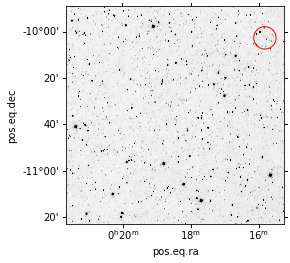

```python
fig = plt.figure()

wcs = WCS(allwise_w1_image[0].header)
ax = fig.add_subplot(1, 1, 1, projection=wcs)
ax.imshow(allwise_w1_image[0].data, cmap='gray_r', origin='lower', vmax = 10)
ax.scatter(ra, dec, transform=ax.get_transform('fk5'), s=500, edgecolor='red', facecolor='none')
```

## 12. Plot a cutout of the AllWISE image, centered on your position.

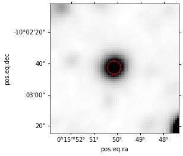

```python
size = 60
cutout = Cutout2D(allwise_w1_image[0].data, pos, (size, size), wcs=wcs)
wcs = cutout.wcs

fig = plt.figure()

ax = fig.add_subplot(1, 1, 1, projection=wcs)
ax.imshow(cutout.data, cmap='gray_r', origin='lower', vmax = 10)
ax.scatter(ra, dec, transform=ax.get_transform('fk5'), s=500, edgecolor='red', facecolor='none')
```

## 13. Try visualizing a cutout of a GALEX image that covers your position.

Repeat steps 4, 5, 6, 8 through 12 for GALEX.

```python
galex_image_services = vo.regsearch(keywords=['galex'], servicetype='image')
print(f'{len(galex_image_services)} result(s) found.')
galex_image_services.to_table()['ivoid', 'short_name', 'res_title']
```

```
5 result(s) found.
```

*Table length=5*

| ivoid object | short_name object | res_title object |
| --- | --- | --- |
| ivo://archive.stsci.edu/sia/galex | GALEX | Galaxy Evolution Explorer |
| ivo://irsa.ipac/spitzer/images/lvl | LVL | Spitzer Local Volume Legacy Survey |
| ivo://irsa.ipac/wise/images/z0mgs | z0MGS | The z=0 Multiwavelength Galaxy Synthesis |
| ivo://mast.stsci/siap/galex_atlas | GALEX_Atlas | GALEX Atlas of Nearby Galaxies |
| ivo://nasa.heasarc/skyview/galex | GALEX | Galaxy Explorer All Sky Survey: Near UV |

```python
galex_image_service = galex_image_services[0]
```

```python
galex_image_table = galex_image_service.search(pos=pos, size=0.0, intersect='covers')
```

```python
for i in range(len(galex_image_table)):
    if (('image/fits' in galex_image_table[i].format) and
        (galex_image_table['enrValue'][i]==2.35e-07)):
        break
galex_image_record = galex_image_table[i]
print(galex_image_record.title, galex_image_record.bandpass_id)
```

```
ais_270_sg14-nd-int.fits.gz UV
```

```python
## See above regarding two ways to do this:
#galex_nuv_image = fits.open(galex_image_record.getdataurl())
file_name = download_file(galex_image_record.getdataurl(), cache=True)
galex_nuv_image=fits.open(file_name)
```

```python
image_data = galex_nuv_image[0].data
print('Min:', np.min(image_data))
print('Max:', np.max(image_data))
print('Mean:', np.mean(image_data))
print('Stdev:', np.std(image_data))
```

```
Min: 0.0
Max: 7.1870303
Mean: 0.0014934327
Stdev: 0.012639926
```

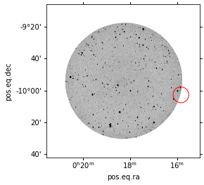

```python
fig = plt.figure()
ax = fig.add_subplot(1, 1, 1, projection=WCS(galex_nuv_image[0].header))
ax.imshow(galex_nuv_image[0].data, cmap='gray_r', origin='lower', vmin=0.0, vmax=0.01)
ax.scatter(ra, dec, transform=ax.get_transform('fk5'), s=500, edgecolor='red', facecolor='none')
```

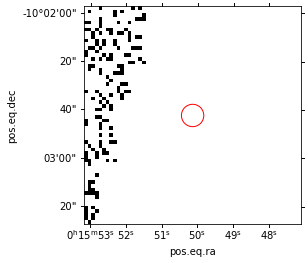

```python
cutout = Cutout2D(galex_nuv_image[0].data, pos, size, wcs=WCS(galex_nuv_image[0].header))

fig = plt.figure()

ax = fig.add_subplot(1, 1, 1, projection=cutout.wcs)
ax.imshow(cutout.data, cmap='gray_r', origin='lower', vmin = 0.0, vmax = 0.01)
ax.scatter(ra, dec, transform=ax.get_transform('fk5'), s=500, edgecolor='red', facecolor='none')
```

## 14. Try visualizing a cutout of an SDSS image that covers your position.

Hints:

- Search the registry using `keywords=['sloan']
- Find the service with a `short_name` of `'SDSS SIAP'`
- From Known Issues, recall that an empty string must be specified to the `format` parameter dues to a bug in the service.
- After obtaining your search results, select r-band images using the `.title` attribute of the records that are returned, since `.bandpass_id` is not populated.

```python
sdss_image_services = vo.regsearch(keywords=['sloan'], servicetype='image')
sdss_image_services.to_table()['ivoid', 'short_name', 'res_title', 'source_value']
```

*Table length=22*

| ivoid object | short_name object | res_title object | source_value object |
| --- | --- | --- | --- |
| ivo://irsa.ipac/spitzer/images/shela | SHELA | Spitzer/HETDEX Exploratory Large-Area Survey |  |
| ivo://mast.stsci/siap/al218 | VLA.AL218 | VLA-A Array AL218 Texas Survey Source Snapshots (AL218) |  |
| ivo://mast.stsci/siap/vla-first | VLA-FIRST | VLA Faint Images of the Radio Sky at Twenty Centimeters (FIRST) |  |
| ivo://nasa.heasarc/skyview/sdss | SDSS | Sloan Digital Sky Survey g-band |  |
| ivo://nasa.heasarc/skyview/sdssdr7 | SDSSDR7 | Sloan Digital Sky Survey g-band DR7 |  |
| ivo://nasa.heasarc/skyview/stripe82vla | Stripe82VLA | VLA Survey of SDSS Stripe 82 |  |
| ivo://org.gavo.dc/bgds/q/sia | bgds sia | Bochum Galactic Disk Survey (BGDS) SIAP service | 2015AN....336..590H |
| ivo://sdss.jhu/services/siap-images | SDSS SIAP | Sloan Digital Sky Survey Images (Latest Release) |  |
| ivo://sdss.jhu/services/siapdr1-images | SDSSDR1 | Sloan Digital Sky Survey DR1 - Images |  |
| ivo://sdss.jhu/services/siapdr2-images | SDSSDR2 | Sloan Digital Sky Survey DR2 - Images |  |
| ivo://sdss.jhu/services/siapdr3-color | SDSSDR3-Color | Sloan Digital Sky Survey DR3 |  |
| ivo://sdss.jhu/services/siapdr3-g | SDSSDR3-G | Sloan Digital Sky Survey DR3 - Filter g |  |
| ivo://sdss.jhu/services/siapdr3-i | SDSSDR3-I | Sloan Digital Sky Survey DR3 - Filter i |  |
| ivo://sdss.jhu/services/siapdr3-r | SDSSDR3-R | Sloan Digital Sky Survey DR3 - Filter r |  |
| ivo://sdss.jhu/services/siapdr3-u | SDSSDR3-U | Sloan Digital Sky Survey DR3 - Filter u |  |
| ivo://sdss.jhu/services/siapdr3-z | SDSSDR3-Z | Sloan Digital Sky Survey DR3 - Filter z |  |
| ivo://sdss.jhu/services/siapdr4-color | SDSSDR4-Color | Sloan Digital Sky Survey DR4 |  |
| ivo://sdss.jhu/services/siapdr4-images | SDSSDR4 | Sloan Digital Sky Survey DR4 - Images |  |
| ivo://sdss.jhu/services/siapdr5-images | SDSSDR5 | Sloan Digital Sky Survey DR5 - Images |  |
| ivo://sdss.jhu/services/siapdr7-images | SDSSDR7 | Sloan Digital Sky Survey DR7 - Images |  |
| ivo://sdss.jhu/services/siapdr8-images | SDSSDR8 | Sloan Digital Sky Survey DR8 - Images |  |
| ivo://sdss.jhu/services/siapdr9-images | SDSSDR9 | Sloan Digital Sky Survey DR9 - Images |  |

```python
#  Use list comprehension to check each service's short_name attribute.
#   Given the above, we know the first match is the right one.
sdss_image_service = [s for s in sdss_image_services if 'SDSS SIAP' in s.short_name ][0]
sdss_image_service.short_name
```

```
'SDSS SIAP'
```

As a workaround to a bug in the SDSS service, pass `format=''` when searching.

```python
sdss_image_table = sdss_image_service.search(pos=pos, size=0.0, format='', intersect='covers')
len(sdss_image_table['Title'])
```

```
60
```

```python
for sdss_rband_record in sdss_image_table:
    if 'Sloan Digital Sky Survey - Filter r' in sdss_rband_record.title:
        break
print(sdss_rband_record.title, sdss_rband_record.bandpass_id)
```

```
Sloan Digital Sky Survey - Filter r None
```

```python
##  See above regarding two ways to do this
# sdss_rband_image = fits.open(sdss_rband_record.getdataurl())
file_name = download_file(sdss_rband_record.getdataurl(), cache=True)
sdss_rband_image=fits.open(file_name)
```

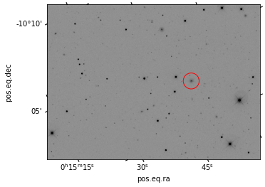

```python
fig = plt.figure()

ax = fig.add_subplot(1, 1, 1, projection=WCS(sdss_rband_image[0].header))

interval = vis.PercentileInterval(99.9)
vmin,vmax = interval.get_limits(sdss_rband_image[0].data)
norm = vis.ImageNormalize(vmin=vmin, vmax=vmax, stretch=vis.LogStretch(1000))
ax.imshow(sdss_rband_image[0].data, cmap = 'gray_r', norm = norm, origin = 'lower')
ax.scatter(ra, dec, transform=ax.get_transform('fk5'), s=500, edgecolor='red', facecolor='none')
```

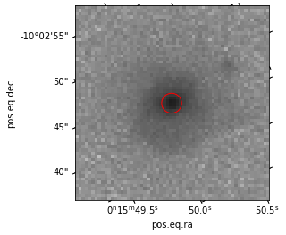

```python
cutout = Cutout2D(sdss_rband_image[0].data, pos, size, wcs=WCS(sdss_rband_image[0].header))
fig = plt.figure()
ax = fig.add_subplot(1, 1, 1, projection=cutout.wcs)
vmin,vmax = interval.get_limits(sdss_rband_image[0].data)
norm = vis.ImageNormalize(vmin=vmin, vmax=vmax, stretch=vis.LogStretch(1000))
ax.imshow(cutout.data, cmap = 'gray_r', norm = norm, origin = 'lower')
ax.scatter(ra, dec, transform=ax.get_transform('fk5'), s=500, edgecolor='red', facecolor='none')
```

## 15. Try looping over all positions and plotting multiwavelength cutouts.

Warning: this cell takes a long time to run! We limit it to the first three galaxies only.

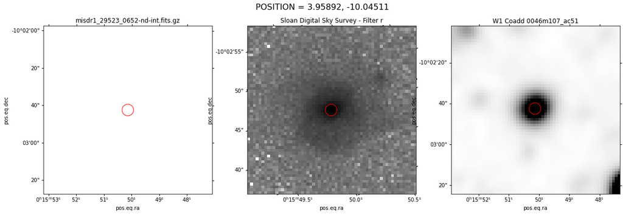

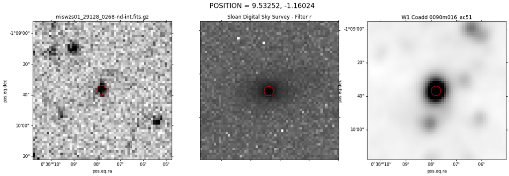

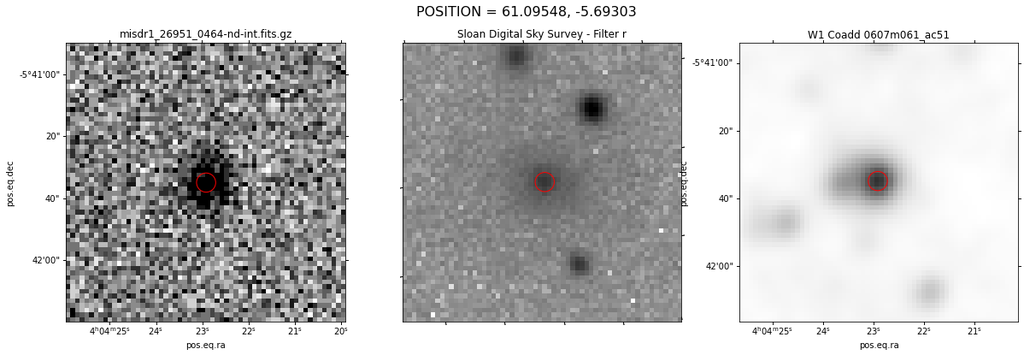

```python
# Pick the first 3 galaxies.
galaxy_subset = galaxies[0:3]

# For each galaxy,
for galaxy in galaxy_subset:

    # Establish the position.
    ra = galaxy['RA']
    dec = galaxy['DEC']
    pos = SkyCoord(ra, dec, unit = 'deg')

    # Set up the plot for this position.
    fig = plt.figure(figsize=(20,6))
    plt.suptitle('POSITION = ' + str(ra) + ', ' + str(dec), fontsize=16)

    # GALEX

    # Find the GALEX images that overlap the position.
    galex_image_table = galex_image_service.search(pos=pos, size=0.25)

    # Find the GALEX All-Sky Image Survey (AIS) Near-UV FITS coadd.
    for i in range(len(galex_image_table)):
        if (('image/fits' in galex_image_table[i].format) and
            (galex_image_table['enrValue'][0]==2.35e-07)):
            break
    galex_image_record = galex_image_table[i]

    # Create a cutout.
    file_name = download_file(galex_image_record.getdataurl(), cache=True)
    gimage=fits.open(file_name)
    galex_cutout = Cutout2D(gimage[0].data, pos, size, wcs=WCS(gimage[0].header))

    # Plot the cutout in the first position of a 1x3 (rowsxcols) grid.
    ax = fig.add_subplot(1, 3, 1, projection=galex_cutout.wcs)
    ax.set_title(galex_image_record.title)
    ax.imshow(galex_cutout.data, cmap='gray_r', origin='lower', vmin = 0.0, vmax = 0.01)
    ax.scatter(ra, dec, transform=ax.get_transform('fk5'), s=500, edgecolor='red', facecolor='none')

    # SDSS

    # Find the SDSS images that overlap the position.
    sdss_image_table = sdss_image_service.search(pos=pos, size=0, format='')

    # Find the first SDSS r-band image.
    for sdss_rband_record in sdss_image_table:
        if 'Sloan Digital Sky Survey - Filter r' in sdss_rband_record.title:
            break
    file_name = download_file(sdss_rband_record.getdataurl(), cache=True)
    sdss_rband_image=fits.open(file_name)

    # Create a cutout.
    sdss_cutout = Cutout2D(sdss_rband_image[0].data, pos, size,
                           wcs=WCS(sdss_rband_image[0].header))

    # Plot the cutout in the second position of a 1x3 grid.
    vmin,vmax = interval.get_limits(sdss_cutout.data)
    norm = vis.ImageNormalize(vmin=vmin, vmax=vmax, stretch=vis.LogStretch(1000))
    ax = fig.add_subplot(1, 3, 2, projection=sdss_cutout.wcs)
    ax.imshow(sdss_cutout.data, cmap = 'gray_r', norm = norm, origin = 'lower')
    ax.scatter(ra, dec, transform=ax.get_transform('fk5'), s=500, edgecolor='red', facecolor='none')
    ax.set_title(sdss_rband_record.title)

    # AllWISE

    # Find the AllWISE images that overlap the position.
    allwise_image_table = allwise_image_service.search(pos=pos, size=0)

    # Find the AllWISE W1 channel images.
    for allwise_image_record in allwise_image_table:
        if 'W1' in allwise_image_record.bandpass_id:
            break
    file_name = download_file(allwise_image_record.getdataurl(), cache=True)
    allwise_w1_image=fits.open(file_name)


    # Create a cutout.
    allwise_cutout = Cutout2D(allwise_w1_image[0].data, pos, (size, size),
                              wcs=WCS(allwise_w1_image[0].header))

    # Plot the cutout in the third position of a 1x3 grid.
    ax = fig.add_subplot(1, 3, 3, projection=allwise_cutout.wcs)
    ax.imshow(allwise_cutout.data, cmap='gray_r', origin='lower', vmax = 10)
    ax.scatter(ra, dec, transform=ax.get_transform('fk5'), s=500, edgecolor='red', facecolor='none')
    ax.set_title(allwise_image_record.title)
```